# Final Data presentation

MAM Group 8

2023-11-19

# Twitch’s Growth

COVID-19 – Twitch has seen an explosion in popularity from users and streamers since the pandemic started.

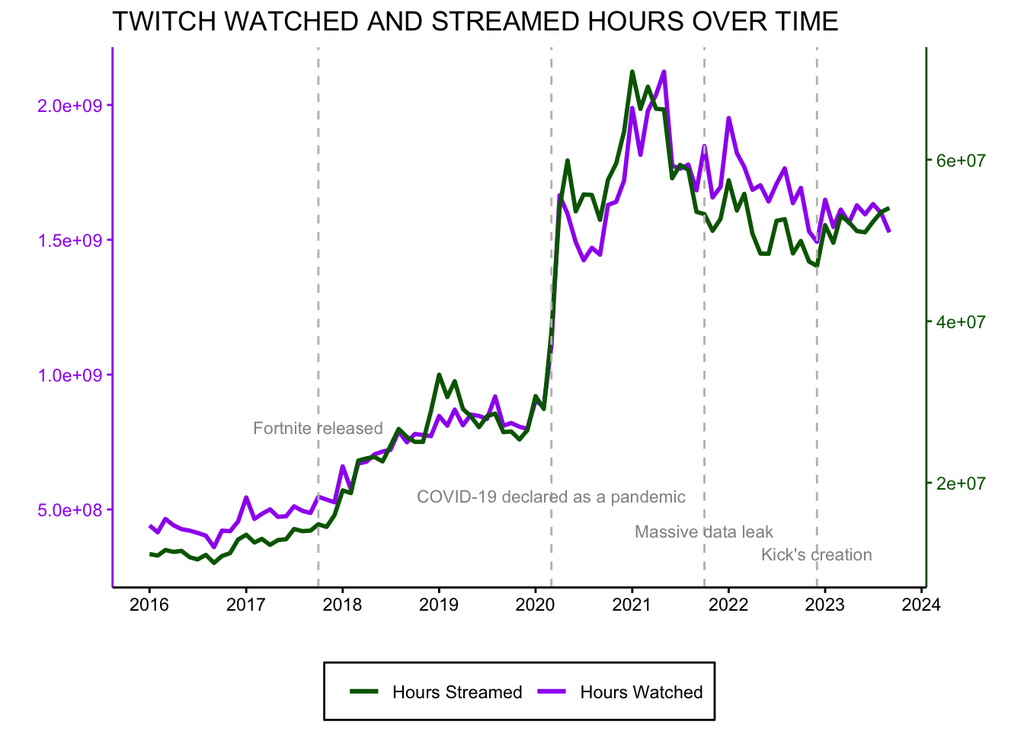

```r
# Convert 'Year' and 'Month' columns to a single date object
# 'make_date()' creates dates from year and month values
twitch_data$Date <- make_date(twitch_data$Year, twitch_data$Month)

# Summarise 'Hours_watched' and 'Hours_streamed' after grouping by date
monthly_data <- twitch_data %>%
  group_by(Date) %>%
  summarise(Hours_watched = sum(Hours_watched),
            Hours_streamed = sum(Hours_streamed))

# Calculate a scale factor for plotting
scale_factor <- max(monthly_data$Hours_watched) / max(monthly_data$Hours_streamed)

# Define important dates with their corresponding labels and y-axis positions
important_dates <- data.frame(
  Date = as.Date(c("2020-03-01", "2021-10-01", "2022-12-01", "2017-10-1")),
  Label = c("COVID-19 declared as a pandemic", "Massive data leak", "Kick's creation", "Fortnite released"),
  y_position = c(max(monthly_data$Hours_watched * 0.28),
                 max(monthly_data$Hours_watched * 0.22),
                 max(monthly_data$Hours_watched * 0.18),
                 max(monthly_data$Hours_watched * 0.4)))  # Adjust y positions to prevent label overlap

# Creating the plot
p2 <- ggplot(monthly_data, aes(x = Date)) +
  geom_line(aes(y = Hours_watched, colour = "Hours Watched"), size = 1) +
  geom_line(aes(y = Hours_streamed * scale_factor, colour = "Hours Streamed"), size = 1) +
  # Setting new colors
  scale_colour_manual("",
                      values = c("Hours Watched" = "purple", "Hours Streamed" = "darkgreen")) +
  # Setting labels and title of the plot
  labs(x = "", y = "", title = "TWITCH WATCHED AND STREAMED HOURS OVER TIME") +
  # Applying a minimal theme and customizing the plot appearance
  theme_minimal() +
  theme(legend.position = "bottom",
        plot.title = element_text(face = "plain"),
        axis.text.x = element_text(color = "black"),
        axis.text.y = element_text(color = "black"),
        axis.line.x = element_line(color = "black"),
        axis.line.y.left = element_line(color = "purple"),
        axis.line.y.right = element_line(color = "darkgreen"),
        panel.grid.major = element_blank(),
        panel.grid.minor = element_blank(),
        axis.ticks = element_line(color = "black"),
        legend.background = element_rect(colour = "black"),
        axis.text.y.left = element_text(color = "purple"),
        axis.text.y.right = element_text(color = "darkgreen"),
        axis.ticks.y.right = element_line(color = "darkgreen"),
        axis.ticks.y.left = element_line(color = "purple")) +
  # Setting continuous y-axis and secondary y-axis for 'Hours_streamed'
  scale_y_continuous(sec.axis = sec_axis(~./scale_factor, name = "")) +
  # Adding vertical lines for important dates and labeling them
  geom_vline(data = important_dates, aes(xintercept = Date), linetype = "dashed", color = "grey") +
  geom_text(data = important_dates, aes(x = Date, y = y_position, label = Label), vjust = 1.5, hjust = 0.5, angle = 0, color = "#909495", size = 3) +
  # Customizing the x-axis to show year labels
  scale_x_date(date_breaks = "1 year", date_minor_breaks = "1 month", date_labels = "%Y")

# Print the plot
p2
```

# Kick’s Growth

Kick Overview – Competitor to Twitch started out strong attracting streamers and users but has lost its momentum with hours watched plateauing and active channels dropping

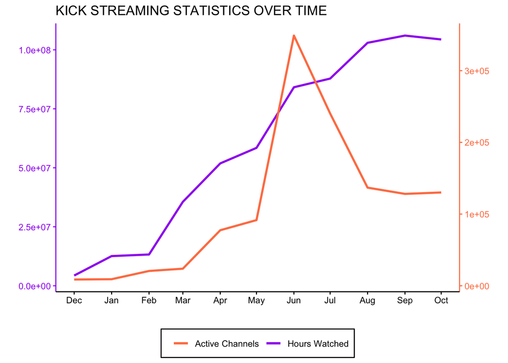

```r
Kick_stats$Month <- dmy(paste("01-", Kick_stats$Month))

# Remove November from the dataset, it is the most recent month
Kick_stats <- Kick_stats %>%
  filter(Month != max(Month))

# Calculate a scale factor for plotting
scale_factor <- max(Kick_stats$Hours.Watched) / max(Kick_stats$Active.Channels)

# Creating the plot
p5 <- ggplot(Kick_stats, aes(x = Month)) +
  geom_line(aes(y = Hours.Watched, colour = "Hours Watched"), size = 1) +
  geom_line(aes(y = Active.Channels * scale_factor, colour = "Active Channels"), size = 1) +
  scale_colour_manual("",
                      values = c("Hours Watched" = "purple", "Active Channels" = "coral")) +
  # Setting labels and title of the plot
  labs(x = "", y = "", title = "KICK STREAMING STATISTICS OVER TIME") +
  # Changing theme
  theme_minimal() +
  # Customizing the plot appearance
  theme(legend.position = "bottom",
        plot.title = element_text(face = "plain"),
        axis.text.x = element_text(color = "black"),
        axis.text.y = element_text(color = "black"),
        axis.line.x = element_line(color = "black"),
        axis.line.y.left = element_line(color = "purple"),
        axis.line.y.right = element_line(color = "coral"),
        panel.grid.major = element_blank(),
        panel.grid.minor = element_blank(),
        axis.ticks = element_line(color = "black"),
        legend.background = element_rect(colour = "black"),
        axis.text.y.left = element_text(color = "purple"),
        axis.text.y.right = element_text(color = "coral"),
        axis.ticks.y.right = element_line(color = "coral"),
        axis.ticks.y.left = element_line(color = "purple")) +
  # Setting continuous y-axis and secondary y-axis for 'Active.Channels'
  scale_y_continuous(sec.axis = sec_axis(~./scale_factor, name = "")) +
  # Customizing the x-axis to show abbreviated month names
  scale_x_date(date_breaks = "1 month", date_labels = "%b")

# Print the plot
p5
```

# Viewer Ratios

Viewership Dynamics – Twitch’s panorama reveals a rising trend in audience numbers with a stable viewer ratio, underscoring a robust and unwavering engagement across the platform.

```r
# Peek at the data
head(Twitch_global_data)
```

```
##   year Month Hours_watched Avg_viewers Peak_viewers Streams Avg_channels
## 1 2016     1     480241904      646355      1275257 7701675        20076
## 2 2016     2     441859897      635769      1308032 7038520        20427
## 3 2016     3     490669308      660389      1591551 7390957        20271
## 4 2016     4     377975447      525696      1775120 6869719        16791
## 5 2016     5     449836631      605432      1438962 7535519        19394
## 6 2016     6     446429345      620903      1755888 6663363        18818
##   Games_streamed Viewer_ratio
## 1          12149        29.08
## 2          12134        28.98
## 3          12234        28.92
## 4          12282        28.80
## 5          12424        28.85
## 6          12374        28.76
```

```r
# Ensure that 'year' and 'Month' are in the correct format
Twitch_global_data$year <- as.integer(as.character(Twitch_global_data$year))
Twitch_global_data$Month <- as.integer(as.character(Twitch_global_data$Month))

# Calculate average viewer ratio for each year
yearly_avg_viewer_ratio <- Twitch_global_data %>%
  group_by(year) %>%
  summarise(AverageViewerRatio = mean(Viewer_ratio, na.rm = TRUE))

yearly_avg_viewer_ratio
```

```
## # A tibble: 8 × 2
##    year AverageViewerRatio
##   <int>              <dbl>
## 1  2016               28.6
## 2  2017               27.1
## 3  2018               25.4
## 4  2019               26.2
## 5  2020               24.9
## 6  2021               27.2
## 7  2022               28.0
## 8  2023               26.3
```

```r
skim(Twitch_global_data)
```

Data summary

| Name | Twitch_global_data |
| --- | --- |
| Number of rows | 93 |
| Number of columns | 9 |
| _______________________ |  |
| Column type frequency: |  |
| numeric | 9 |
| ________________________ |  |
| Group variables | None |

**Variable type: numeric**

| skim_variable | n_missing | complete_rate | mean | sd | p0 | p25 | p50 | p75 | p100 | hist |
| --- | --- | --- | --- | --- | --- | --- | --- | --- | --- | --- |
| year | 0 | 1 | 2.019390e+03 | 2.25 | 2016.00 | 2017.00 | 2019.00 | 2.021000e+03 | 2.023000e+03 | ▇▃▇▃▇ |
| Month | 0 | 1 | 6.350000e+00 | 3.43 | 1.00 | 3.00 | 6.00 | 9.000000e+00 | 1.200000e+01 | ▇▅▅▅▇ |
| Hours_watched | 0 | 1 | 1.222745e+09 | 617536976.66 | 362833210.00 | 601251200.00 | 949050474.00 | 1.817120e+09 | 2.308295e+09 | ▇▆▁▇▃ |
| Avg_viewers | 0 | 1 | 1.677215e+06 | 847592.30 | 504635.00 | 809220.00 | 1313721.00 | 2.520054e+06 | 3.112681e+06 | ▇▆▁▇▃ |
| Peak_viewers | 0 | 1 | 3.446440e+06 | 1638765.14 | 1186009.00 | 1835725.00 | 2933491.00 | 4.816995e+06 | 6.707070e+06 | ▇▅▃▆▃ |
| Streams | 0 | 1 | 1.609115e+07 | 6343214.11 | 5507554.00 | 9288649.00 | 15769306.00 | 2.216466e+07 | 2.759115e+07 | ▇▃▇▇▅ |
| Avg_channels | 0 | 1 | 6.331075e+04 | 33446.89 | 16592.00 | 28181.00 | 53882.00 | 9.416400e+04 | 1.227630e+05 | ▇▆▁▇▃ |
| Games_streamed | 0 | 1 | 2.638678e+04 | 11193.57 | 12134.00 | 16871.00 | 20536.00 | 3.640600e+04 | 4.457100e+04 | ▇▇▁▅▆ |
| Viewer_ratio | 0 | 1 | 2.672000e+01 | 1.55 | 22.65 | 25.71 | 26.79 | 2.804000e+01 | 3.039000e+01 | ▁▅▇▆▂ |

```r
summary(Twitch_global_data$Viewer_ratio)
```

```
##    Min. 1st Qu.  Median    Mean 3rd Qu.    Max.
##   22.65   25.71   26.79   26.72   28.04   30.39
```

```r
# Calculate year-over-year changes
yearly_avg_viewer_ratio <- yearly_avg_viewer_ratio %>%
  arrange(year) %>%
  mutate(Change = (AverageViewerRatio - lag(AverageViewerRatio)) / lag(AverageViewerRatio) * 100)

yearly_avg_viewer_ratio
```

```
## # A tibble: 8 × 3
##    year AverageViewerRatio Change
##   <int>              <dbl>  <dbl>
## 1  2016               28.6  NA
## 2  2017               27.1  -5.23
## 3  2018               25.4  -6.31
## 4  2019               26.2   2.97
## 5  2020               24.9  -5.04
## 6  2021               27.2   9.24
## 7  2022               28.0   3.27
## 8  2023               26.3  -6.27
```

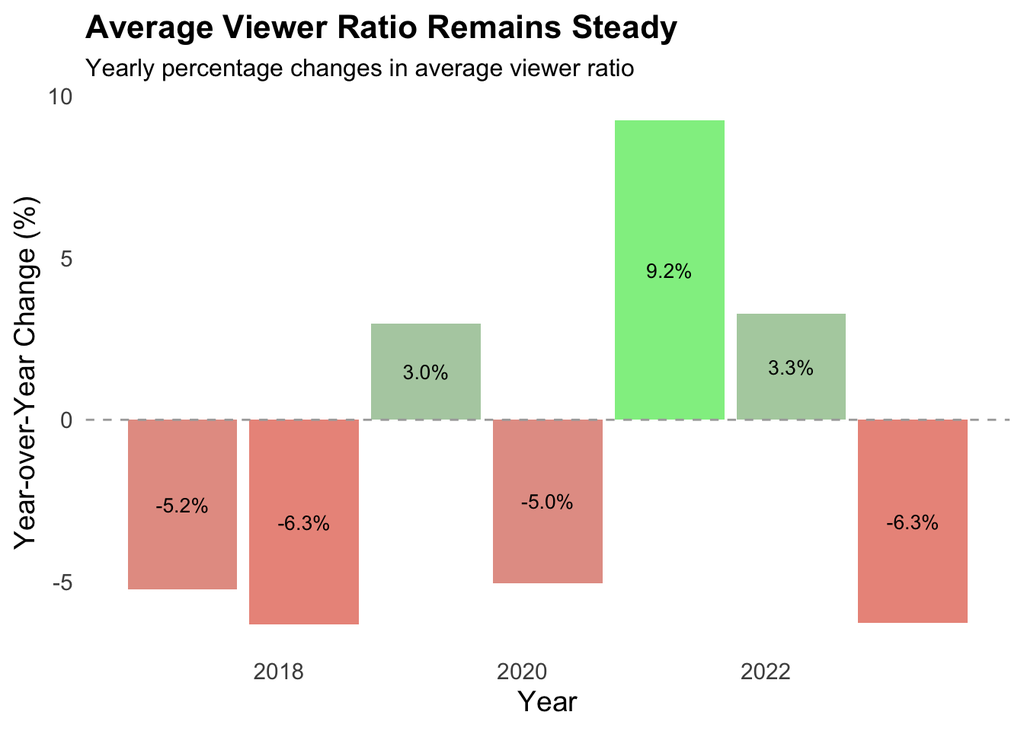

```r
library(ggplot2)
library(scales)  # For percent_format()

# Assuming 'yearly_avg_viewer_ratio' is a dataframe with 'Year' and 'Change' columns
# Plotting the year-over-year changes
ggplot(data = yearly_avg_viewer_ratio, aes(x = year, y = Change)) +
  geom_col(aes(fill = Change), show.legend = FALSE) +  # Use fill aesthetic for automatic color grading
  scale_fill_gradient2(low = "salmon", high = "lightgreen", mid = "grey", midpoint = 0) +  # Gradient color scheme
  geom_text(aes(label = scales::percent(Change / 100, accuracy = .1)), position = position_stack(vjust = 0.5), color = "black", size = 3.5) +  # Add labels
  theme_minimal(base_size = 14) +  # Clean theme
  theme(
    axis.text.x = element_text(hjust = 1),  # Angle x-axis text
    plot.title = element_text(size = 16, face = "bold"),  # Bold title
    plot.subtitle = element_text(size = 12),  # Subtitle
    panel.grid.major = element_blank(),  # Remove major grid lines
    panel.grid.minor = element_blank(),  # Remove minor grid lines
    panel.background = element_blank()   # Remove panel background
  ) +
  labs(
    title = "Average Viewer Ratio Remains Steady",
    subtitle = "Yearly percentage changes in average viewer ratio",
    x = "Year",
    y = "Year-over-Year Change (%)"
  ) +
  geom_hline(yintercept = 0, linetype = "dashed", color = "darkgrey")   # Reference line at 0%
```

The average for Twitch viewer ratio centered around 26. The chart reflects a stable annual change in Twitch’s average viewer ratio, mostly within a 10% range, signifying consistent dynamics between viewers and existing channels.

# Correlation with Channels

A surge in Twitch viewership during the 2020-2021 period is likely attributed to the COVID-19 lockdowns, followed by a normalization post-pandemic as audiences spend less time on live streaming. Several peak viewerships have resulted from major gaming tournament like dota2, LOL, and PUBG.

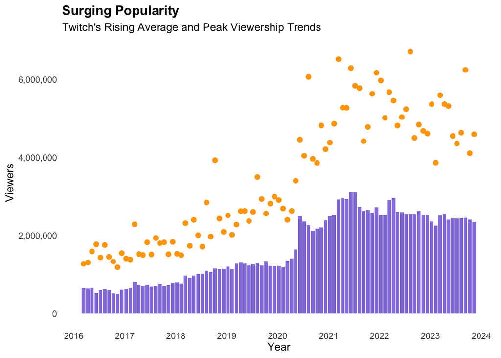

```r
# Assuming Twitch_global_data is your dataframe and it has columns for 'year', 'Month', 'Avg_viewers', 'Peak_viewers'

# Create a Date column from year and month
Twitch_global_data$Date <- make_date(Twitch_global_data$year, Twitch_global_data$Month)

# Create the plot with a more gentle color for the bars and smaller points for peak viewers
ggplot(Twitch_global_data, aes(x = Date)) +
  geom_bar(aes(y = Avg_viewers), stat = "identity", fill = "#5D3FD3", alpha = 0.7) + # Lighter blue color
  geom_point(aes(y = Peak_viewers), color = "orange", size = 2) + # Smaller points
  scale_x_date(labels = date_format("%Y"), breaks = date_breaks("1 year")) +
  scale_y_continuous(labels = comma) +
  labs(title = "Surging Popularity",
    subtitle = "Twitch's Rising Average and Peak Viewership Trends",
       x = "Year",
       y = "Viewers") +

theme_minimal() +
  theme(
    plot.title = element_text(face = "bold"),
    panel.grid = element_blank(),

    axis.text.x = element_text(vjust = 0.5, hjust=1))
```

# Genres

```r
# Select the top 10 genres by total hours watched
top_10_genres <- Twitch_game_data %>%
  group_by(genre) %>%
  summarise(Total_hours_watched = sum(hours_watched)) %>%
  arrange(desc(Total_hours_watched)) %>%
  filter(genre != "Shooter") %>%
  top_n(5)
# Filter Twitch_genre_perf to include only the top 10 genres
top_10_data <- Twitch_game_data %>%
  filter(genre %in% top_10_genres$genre) %>%
  group_by(genre, year) %>%
  summarise(Total_hours_watched = sum(hours_watched))
```

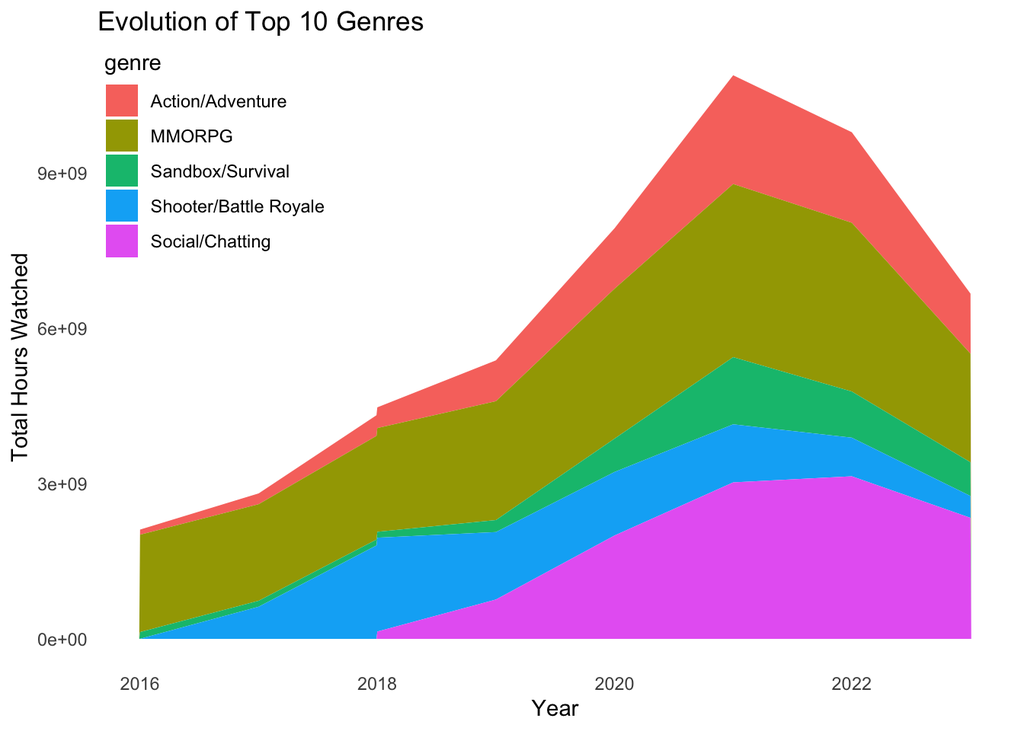

```r
Top10_genres_watched <- ggplot(top_10_data, aes(x = year, y = Total_hours_watched, fill = genre)) +
  geom_area() +
  labs(title = "Evolution of Top 10 Genres",
       x = "Year",
       y = "Total Hours Watched") +
  theme_minimal() +
  theme(panel.grid = element_blank(),  # Remove all gridlines
        legend.position = c(0.01, 0.99),  # Top left corner
        legend.justification = c(0.01, 0.99),  # Top left corner
        legend.box.margin = margin(0, 0, 0, 0),  # Reduce margin around legend
        legend.margin = margin(0, 0, 0, 0))  # Reduce margin around legend


Top10_genres_watched
```

```r
# Select the top 10 genres by total hours watched
top_10_genres <- Twitch_game_data %>%
  group_by(genre) %>%
  summarise(Total_hours_watched = sum(hours_watched)) %>%
  arrange(desc(Total_hours_watched)) %>%
  top_n(10)
# Filter Twitch_genre_perf to include only the top 10 genres
top_10_data <- Twitch_game_data %>%
  filter(genre %in% top_10_genres$genre) %>%
  group_by(genre, year) %>%
  summarise(Total_hours_watched = sum(hours_watched))
# Create a new column to identify if the genre is in the top 10 or not
Twitch_game_data <- Twitch_game_data %>%
  mutate(is_top_10 = ifelse(genre %in% top_10_genres$genre, "Top 10", "Others"))

total_hours_by_group <- Twitch_game_data %>%
  group_by(year, is_top_10) %>%
  summarise(Total_hours_watched = sum(hours_watched)) %>%
  mutate(Percentage = (Total_hours_watched / sum(Total_hours_watched)) * 100)
```

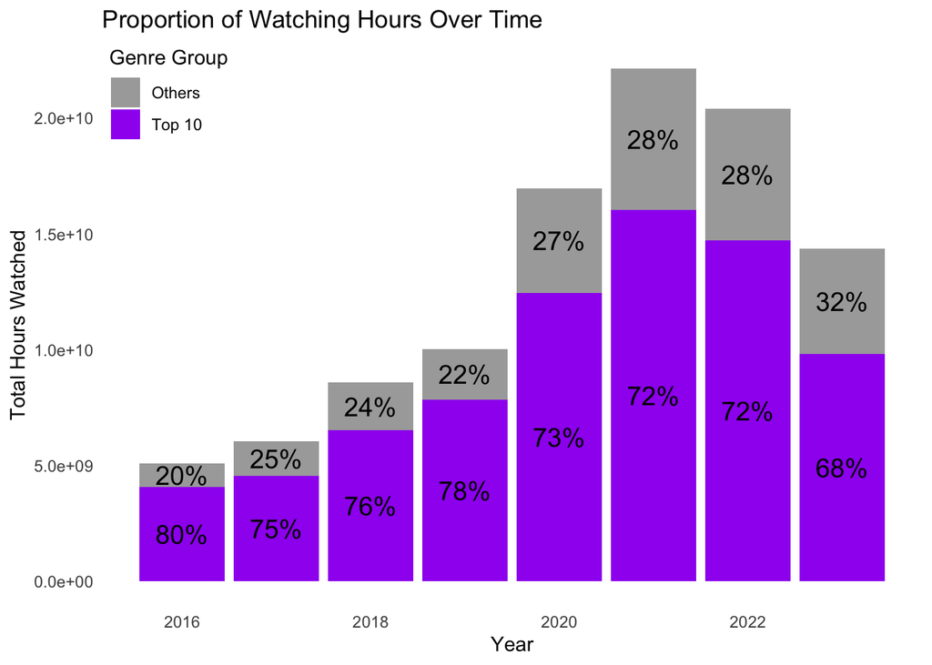

```r
# Plotting the stacked bar chart
Proportion_top10 <- ggplot(total_hours_by_group, aes(x = year, y = Total_hours_watched, fill = is_top_10)) +
  geom_bar(stat = "identity") +
  labs(title = "Proportion of Watching Hours Over Time",
       x = "Year",
       y = "Total Hours Watched",
       fill = "Genre Group") +
  scale_fill_manual(values = c("Top 10" = "purple", "Others" = "darkgrey")) +
  theme_minimal() +
  theme(panel.grid = element_blank(),
        legend.position = c(0.01, 0.99),
        legend.justification = c(0.01, 0.99),
        legend.box.margin = margin(0, 0, 0, 0),
        legend.margin = margin(0, 0, 0, 0)) +
  geom_text(aes(label = paste0(round(Percentage), "%")),
            position = position_stack(vjust = 0.5),
            color = "Black",
            size = 5)

Proportion_top10
```

The chart reveals shifting genre popularity dynamics on Twitch from 2016 to 2022. Notably, the proportion of watching hours for the top 10 genre groups declines, signaling a viewer preference shift towards other genres. This trend reflects a diversifying Twitch platform.

# Drilling down for Games

Popularity of Games/Content – Just Chatting leads the platform in total hours watched on contents after 2020, highlighting a significant shift towards more interactive and community-driven content on Twitch

```r
print(df_game)
```

```
## # A tibble: 18,600 × 12
##     Rank Game              Month  Year Hours_watched Hours_streamed Peak_viewers
##    <dbl> <chr>             <chr> <dbl>         <dbl>          <dbl>        <dbl>
##  1     1 League of Legends 01     2016      94377226        1362044       530270
##  2     2 Counter-Strike: … 01     2016      47832863         830105       372654
##  3     3 Dota 2            01     2016      45185893         433397       315083
##  4     4 Hearthstone       01     2016      39936159         235903       131357
##  5     5 Call of Duty: Bl… 01     2016      16153057        1151578        71639
##  6     6 Minecraft         01     2016      10231056         490002        64432
##  7     7 World of Warcraft 01     2016       8771452         342978        46130
##  8     8 Z1: Battle Royale 01     2016       7894571         205569        41588
##  9     9 Talk Shows & Pod… 01     2016       7688369          53235        84051
## 10    10 FIFA 16           01     2016       6988475         203646       145728
## # ℹ 18,590 more rows
## # ℹ 5 more variables: Peak_channels <dbl>, Streamers <dbl>, Avg_viewers <dbl>,
## #   Avg_channels <dbl>, Avg_viewer_ratio <dbl>
```

```r
print(head(df_game))
```

```
## # A tibble: 6 × 12
##    Rank Game               Month  Year Hours_watched Hours_streamed Peak_viewers
##   <dbl> <chr>              <chr> <dbl>         <dbl>          <dbl>        <dbl>
## 1     1 League of Legends  01     2016      94377226        1362044       530270
## 2     2 Counter-Strike: G… 01     2016      47832863         830105       372654
## 3     3 Dota 2             01     2016      45185893         433397       315083
## 4     4 Hearthstone        01     2016      39936159         235903       131357
## 5     5 Call of Duty: Bla… 01     2016      16153057        1151578        71639
## 6     6 Minecraft          01     2016      10231056         490002        64432
## # ℹ 5 more variables: Peak_channels <dbl>, Streamers <dbl>, Avg_viewers <dbl>,
## #   Avg_channels <dbl>, Avg_viewer_ratio <dbl>
```

```r
# Check for missing values
print(sum(is.na(df_game$Game)))
```

```
## [1] 1
```

```r
# Drop rows with missing 'Game' values
df_game_clean <- df_game %>% filter(!is.na(Game))

# Grouping data by 'Game' and 'Year', and summing a particular column (e.g., 'Hours Watched')
dummydf <-
  df_game_clean %>%
  group_by(Game) %>%
  summarise(Total_Hours = sum(Hours_watched, na.rm = TRUE))%>%
    arrange(desc(Total_Hours)) %>%
  slice_max(order_by = Total_Hours, n = 5)


#Creating a grouped data frame for values present in dummy df
grouped_data <-
  df_game_clean %>%
  group_by(Game, Year) %>%
  summarise(Total_Hours = sum(Hours_watched, na.rm = TRUE))%>%
  filter(Game %in% dummydf$Game)%>%
  arrange(desc(Total_Hours))
```

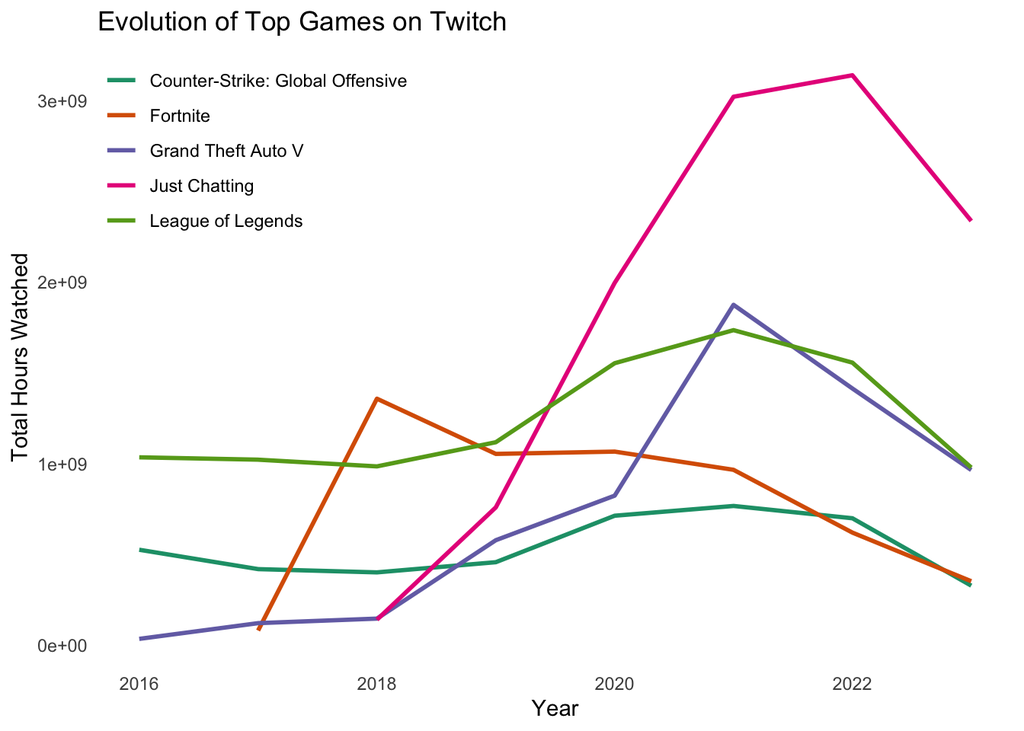

```r
# Example plot (adjust according to specific requirements)
ggplot(grouped_data, aes(x = Year, y = Total_Hours, group = Game, color = Game)) +
  geom_line(size = 1) +
  theme_minimal() +
  theme(panel.grid = element_blank(),
        legend.position = c(0.01, 0.99),  # Top left corner
        legend.justification = c(0.01, 0.99),  # Top left corner
        legend.box.margin = margin(0, 0, 0, 0),  # Reduce margin around legend
        legend.margin = margin(0, 0, 0, 0),
        legend.title = element_blank()) +  # Reduce margin around legend
  labs(y='Total Hours Watched',
       title = 'Evolution of Top Games on Twitch')+

  scale_color_brewer(palette="Dark2")
```

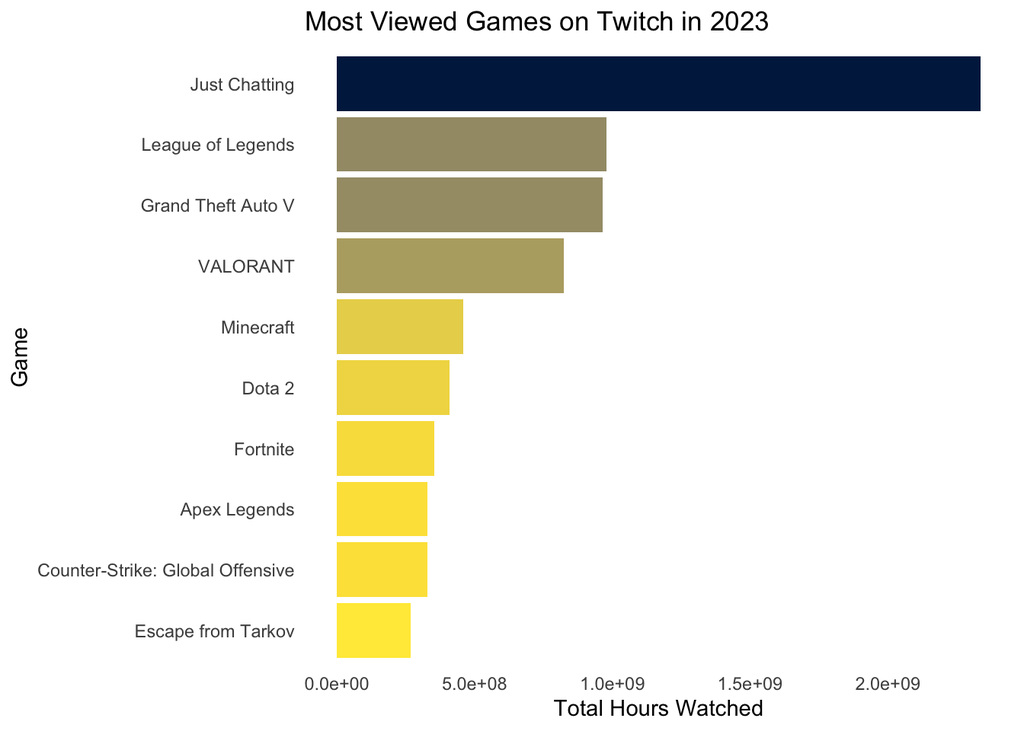

```r
#Creating a grouped data frame for values for 2023
grouped_data <-
  df_game_clean %>%
  filter(Year == '2023') %>%
  group_by(Game) %>%
  summarise(Total_Hours = sum(Hours_watched, na.rm = TRUE))%>%
  slice_max(order_by = Total_Hours, n = 10) %>%
  arrange(desc(Total_Hours)) %>%
  mutate(Game = fct_reorder(Game, Total_Hours))

# Plot
ggplot(grouped_data, aes(x = Total_Hours , y = Game, fill = Total_Hours)) +
  geom_col(show.legend = FALSE) +
  theme_minimal() +
  theme(panel.grid = element_blank()) +  # Disable gridlines
  labs(x='Total Hours Watched',
       title = 'Most Viewed Games on Twitch in 2023')+
  scale_fill_viridis(option = 'cividis',direction = -1) #Reversing the cividis palette
```

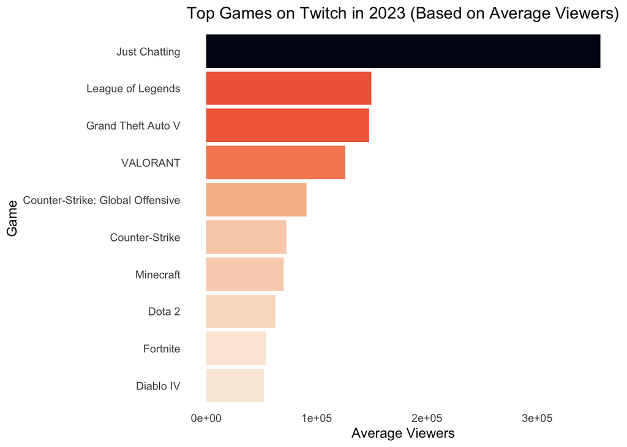

```r
#Creating a grouped data frame for values for 2023
grouped_data <-
  df_game_clean %>%
  filter(Year == '2023') %>%
  group_by(Game) %>%
  summarise(Avg_viewers = mean(Avg_viewers, na.rm = TRUE))%>%
  slice_max(order_by = Avg_viewers, n = 10) %>%
  arrange(desc(Avg_viewers)) %>%
  mutate(Game = fct_reorder(Game, Avg_viewers))

# Plot
ggplot(grouped_data, aes(x = Avg_viewers , y = Game, fill = Avg_viewers)) +
  geom_col(show.legend = FALSE) +
  theme_minimal() +
  theme(panel.grid = element_blank()) +  # Disable gridlines
  labs(x='Average Viewers',
       title = 'Top Games on Twitch in 2023 (Based on Average Viewers)')+
  scale_fill_viridis(option = 'rocket',direction = -1) #Reversing the rocket palette
```

Game Streaming Titans – Among the global top 20 streamers, Twitch commands with 16 leading streamers, showcasing the its dominance in watch hours and broadcaster influence

[figure not shown]

```r
#Distribution of top streamers in the World. Used Tableau to render on a world map
knitr::include_graphics("screenshots/World.png")
```

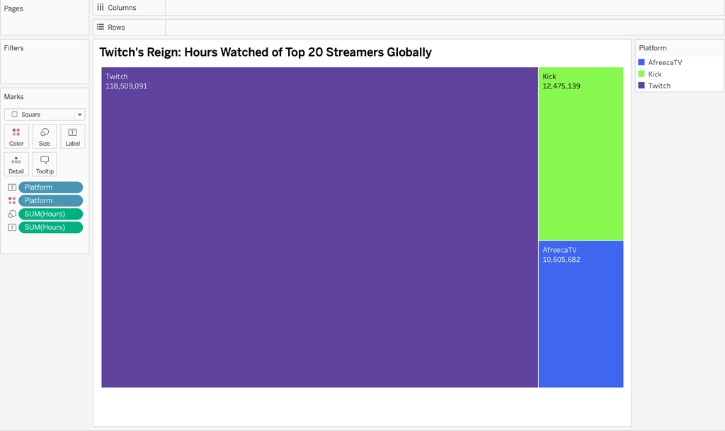

```r
#Treemap created in Tableau
knitr::include_graphics("screenshots/Tableau Screenshot.png")
```